# IODS course project

# Introduction to Open Data Science

# About the project

In this course the aim is to practice coding, recoding, programming and to analyze and visualize open data.

Link to my github repository:

https://github.com/hhautakangas/IODS-project

# Data wrangling R code

```r
## Heidi Hautakangas, 29.01.2017
## Week 2: Regression and model validation

# DATA WRANGLING

# 2. Read data

LEARN <- read.table("http://www.helsinki.fi/~kvehkala/JYTmooc/JYTOPKYS3-data.txt", as.is=T, header=T)
dim(LEARN)
str(LEARN)

attach(LEARN)
# Data contains 183 observations and 60 variables. 59 variables are integers and one variable is character.

# 3. Subsetting data gender, age, attitude, deep, stra, surf and points by combining questions in the learning2014 data
# check names
names(LEARN)

# create new variable Deep (back to original scale divide by 12)
d_sm <- D03+D11+D19+D27
d_ri <- D07+D14+D22+D30
d_ue <- D06+D15+D23+D31

LEARN$Deep <- (d_sm+d_ri+d_ue)/12

# create new variable Surf (back to original scale divide by 12)
su_lp <- SU02+SU10+SU18+SU26
su_um <- SU05+SU13+SU21+SU29
su_sb <- SU08+SU16+SU24+SU32

LEARN$Surf <- (su_lp+su_um+su_sb)/12

#create new variable Stra (back to original scale divide by 8)
st_os <- ST01+ST09+ST17+ST25
st_tm <- ST04+ST12+ST20+ST28

LEARN$Stra <- (st_os+st_tm)/8

# create subset that contains following variables: gender, Age, Attitude, Points, Deep, Stra, Surf
# and exclude observations where points is zero
LEARNsub <- subset(LEARN, Points != 0, select=c(gender, Age, Attitude, Points, Deep, Stra, Surf))

# check subset dimension, should be 166 obs and 7 variables
dim(LEARNsub)

# 3. Set iods folder as working directory
setwd("~/Documents/IODS-project")

# write subset as a new file in the data folder
write.table(LEARNsub, "~/Documents/IODS-project/data/learning2014sub.txt", quote=FALSE, row.names = FALSE, col.names = TRUE)

# read data again
LEARNsub2 <- read.table("data/learning2014sub.txt", as.is=TRUE, header=TRUE)

# check that the structure is ok
str(LEARNsub2)
head(LEARNsub2)
```

# WEEK 2

## ANALYSIS

```r
# read data
setwd("~/Documents/IODS-project")
LEARN <- read.table("data/learning2014sub.txt", as.is=TRUE, header=TRUE)

# attach the data so there is no need to refer to the dataset used
attach(LEARN)
# structure and dimension of the data
dim(LEARN)
```

```
## [1] 166   7
```

```r
str(LEARN)
```

```
## 'data.frame':    166 obs. of  7 variables:
##  $ gender  : chr  "F" "M" "F" "M" ...
##  $ Age     : int  53 55 49 53 49 38 50 37 37 42 ...
##  $ Attitude: int  37 31 25 35 37 38 35 29 38 21 ...
##  $ Points  : int  25 12 24 10 22 21 21 31 24 26 ...
##  $ Deep    : num  3.58 2.92 3.5 3.5 3.67 ...
##  $ Stra    : num  3.38 2.75 3.62 3.12 3.62 ...
##  $ Surf    : num  2.58 3.17 2.25 2.25 2.83 ...
```

```r
# summary of the data
summary(LEARN)
```

```
##     gender               Age           Attitude         Points
##  Length:166         Min.   :17.00   Min.   :14.00   Min.   : 7.00
##  Class :character   1st Qu.:21.00   1st Qu.:26.00   1st Qu.:19.00
##  Mode  :character   Median :22.00   Median :32.00   Median :23.00
##                     Mean   :25.51   Mean   :31.43   Mean   :22.72
##                     3rd Qu.:27.00   3rd Qu.:37.00   3rd Qu.:27.75
##                     Max.   :55.00   Max.   :50.00   Max.   :33.00
##       Deep            Stra            Surf
##  Min.   :1.583   Min.   :1.250   Min.   :1.583
##  1st Qu.:3.333   1st Qu.:2.625   1st Qu.:2.417
##  Median :3.667   Median :3.188   Median :2.833
##  Mean   :3.680   Mean   :3.121   Mean   :2.787
##  3rd Qu.:4.083   3rd Qu.:3.625   3rd Qu.:3.167
##  Max.   :4.917   Max.   :5.000   Max.   :4.333
```

Plot 1. contains boxplots, distributions and scatter plots between all variables classified by gender. Gender is not distributed evenly, there are almost twice as many female observations (n= 110) than male observations (n=56). Most of the scatterplots shows that there is very negligible correlation between variables. Exceptions are between variables Attitude and Points with correlation 0.437, and between Deep and Surf with negative correlation 0.324. From both density and box plots, it can be seen, that there is difference between answers of male and female groups. This can also be observed from the correlations: for example, between variables Deep and Surf, males has strong negative correlation (-0.622), whereas correlation in females is negligible (-0.087). All distributions of female observations has more than one peak, so it can be assumed that they are not normally distributed. Also for male, distributions of Attitude and Points has clearly several peaks. Age is positively skewed in both genders.

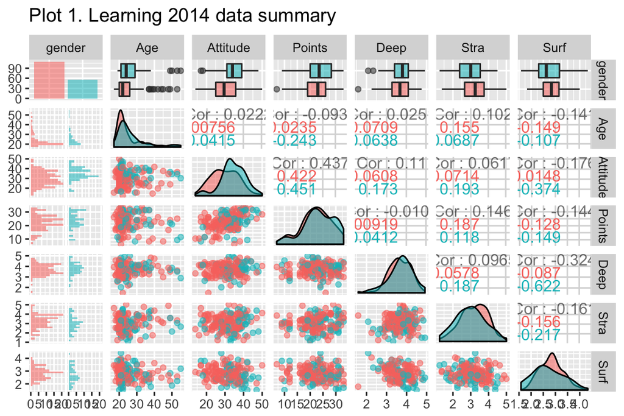

```r
## plot with title added
p <- ggpairs(LEARN, mapping = aes(col = gender, alpha = 0.3), lower = list(combo = wrap("facethist", bins = 20)))
LEARNp <- p + ggtitle("Plot 1. Learning 2014 data summary")
LEARNp
```

### Linear regression

```r
# linear regression
# dependent variable Points
# explanatory variables Age, gender and Attitude

lm1 <- lm(Points ~ Age + gender + Attitude, data=LEARN)
print(summary(lm1))
```

```
##
## Call:
## lm(formula = Points ~ Age + gender + Attitude, data = LEARN)
##
## Residuals:
##      Min       1Q   Median       3Q      Max
## -17.4590  -3.3221   0.2186   4.0247  10.4632
##
## Coefficients:
##             Estimate Std. Error t value Pr(>|t|)
## (Intercept) 13.42910    2.29043   5.863 2.48e-08 ***
## Age         -0.07586    0.05367  -1.414    0.159
## genderM     -0.33054    0.91934  -0.360    0.720
## Attitude     0.36066    0.05932   6.080 8.34e-09 ***
## ---
## Signif. codes:  0 '***' 0.001 '**' 0.01 '*' 0.05 '.' 0.1 ' ' 1
##
## Residual standard error: 5.315 on 162 degrees of freedom
## Multiple R-squared:  0.2018, Adjusted R-squared:  0.187
## F-statistic: 13.65 on 3 and 162 DF,  p-value: 5.536e-08
```

```r
# second model Attitude as an explanatory variable
lm2 <- lm(Points ~ Attitude, data=LEARN)
print(summary(lm2))
```

```
##
## Call:
## lm(formula = Points ~ Attitude, data = LEARN)
##
## Residuals:
##      Min       1Q   Median       3Q      Max
## -16.9763  -3.2119   0.4339   4.1534  10.6645
##
## Coefficients:
##             Estimate Std. Error t value Pr(>|t|)
## (Intercept) 11.63715    1.83035   6.358 1.95e-09 ***
## Attitude     0.35255    0.05674   6.214 4.12e-09 ***
## ---
## Signif. codes:  0 '***' 0.001 '**' 0.01 '*' 0.05 '.' 0.1 ' ' 1
##
## Residual standard error: 5.32 on 164 degrees of freedom
## Multiple R-squared:  0.1906, Adjusted R-squared:  0.1856
## F-statistic: 38.61 on 1 and 164 DF,  p-value: 4.119e-09
```

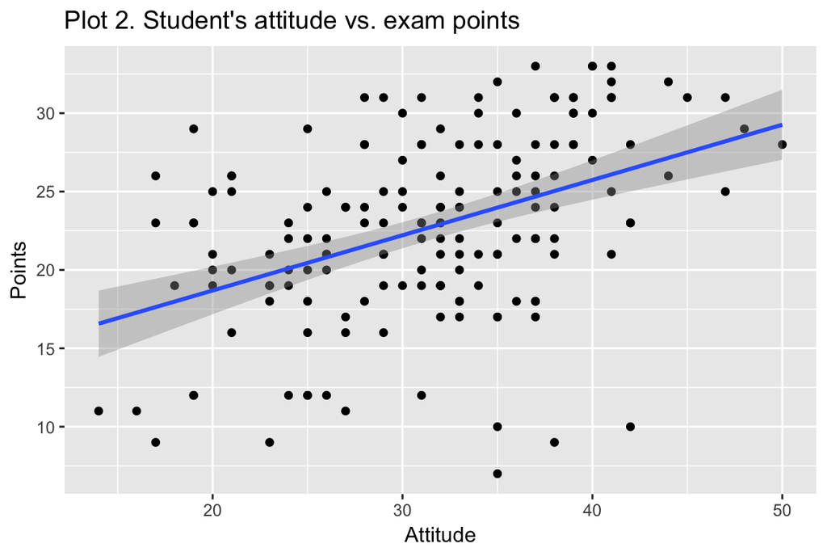

```r
# scatter plot between Attitude and Points
p2 <- qplot(Attitude, Points, data = LEARN) + geom_smooth(method = "lm")
p3 <- p2 + ggtitle("Plot 2. Student's attitude vs. exam points")
p3
```

T-test tests an effect of a given variable to the explanatory variable by testing if the variable differs from zero statistically significantly, and produces T-value that is used to estimate if this null hypothesis can be rejected or accepted. In regression analysis, F-test tests whether explanatory variables can be used to model the variation of the dependant variable. For both models, F-statistics was statistically significant: in the first model p-value was less than 5.54e-08, and in the second model p-value was under 4.1e-09. F-test and R^2 are used to test power of the test. R^2 is the coefficient of determination which describes the proportion of the variation of the dependant variable that can be explained by explanatory variables in the regression model. It varies between 0 and 1, small R^2 indicating that explanatory variables explains only small amount of the variation of the dependant variable and high R^2 vice versa. In the first model, R^2 was 0.20, whereas in the second model it was 0.19. Adjusted R^2 considers also the amount of the explanatory variables and is used to compare the results of different regression models. Adjusted R^2 was 0.187 in the first model and 0.186 in the second model with only one explanatory variable.

Residual standard error describes standard deviation of the residuals and affects to the power of the test. The higher deviation and thus residual standard error, the smaller is the power of the test. Both of the models has quite big residual standard errors, approximately 5.32.

Linear regression assumes that the relationship between variables is linear. Errors are assumed to be normally distributed and not correlated. Homoskedasticity of the errors is also assumed, meaning that variance is constant and does not depend on the observation. Heteroskedasticity can be though handled, for example by weighting variables by the inverse of the variance. Leverage measures the amount of impact a single observation has on the model, and residuals vs leverage plot can be used to identify observations with unusually high impact.

For model validation, I examined these assumptions by producing three plots from the second model: Residuals vs Fitted, Normal QQ-plot and Residuals vs Leverage. Plot 3b. shows that the normality assumption of the errors holds. Plot 3a. is used to examine homoskedasticity. Observations are scattered and do not show any systematic pattern, so the homoskedasticity assumption is also valid. Plot 3c. shows that the leverage is regular and there is no observation with unusually high impact. Model is thus valid.

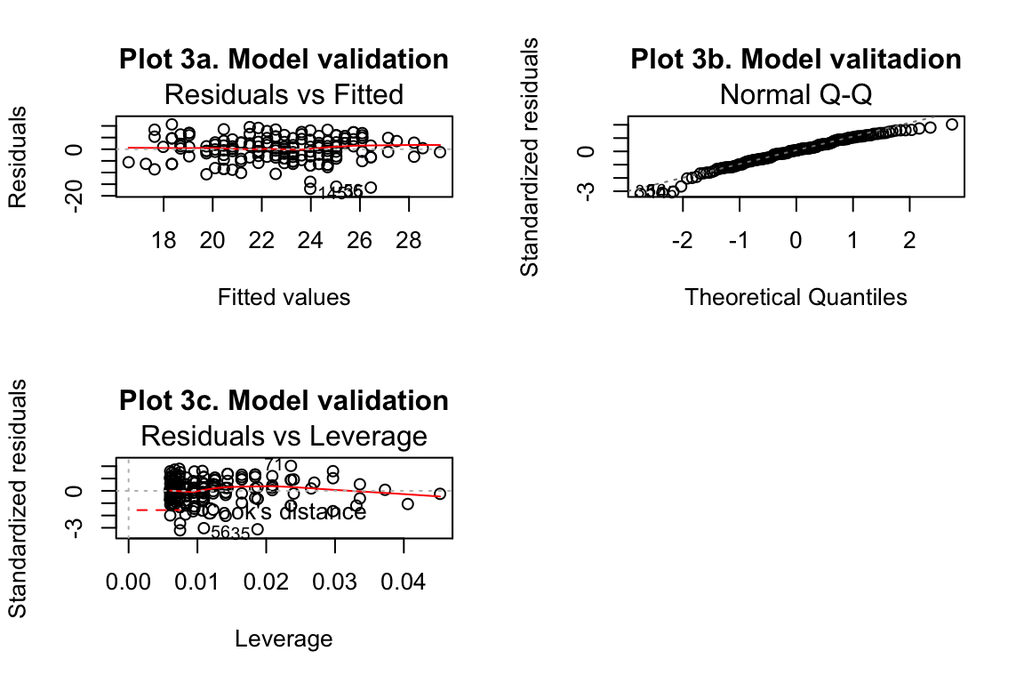

```r
## Plots for validation
par(mfrow= c(2,2))
plot(lm2, which=c(1), main="Plot 3a. Model validation")
plot(lm2, which=c(2), main="Plot 3b. Model valitadion")
plot(lm2, which=c(5), main="Plot 3c. Model validation")
```

# WEEK 3

## ANALYSIS

### Data

```r
# names and summary
names(ALC)
dim(ALC)
str(ALC)
summary(ALC)
```

[output not shown]

### Hypotheses

To study possible factors that might have relationship with high/low alcohol consumption, I chose following four variables: sex, absences, romantic and studytime. Sex and romantic are binary variables, and studytime and absences numeric variables. Hypotheses about their relationship between alcohol consumption are:

Sex:

H0: Sex does not affect on the alcohol consumption,

H1: Alcohol consumption differs between males and females

Romantic:

H0: Being in a romantic relationship does not affect on alcohol consumption

H1: Being in a romantic relationship lessens the alcohol consumption

Absences:

H0: There is no relatioship between alcohol consumption and number of absences

H1: Those whit higher alcohol consumption have more absences

Studytime:

H0: There is no relationship between studytime and alcohol consumption

H1: Those who study more use less alcohol

At start, these relationships are examined from graphics and tables.

```r
# tables and plots
# table 1
ALC %>% group_by(high_use, sex) %>% summarise(count = n())
```

```
## Source: local data frame [4 x 3]
## Groups: high_use [?]
##
##   high_use   sex count
##      <lgl> <chr> <int>
## 1    FALSE     F   156
## 2    FALSE     M   112
## 3     TRUE     F    42
## 4     TRUE     M    72
```

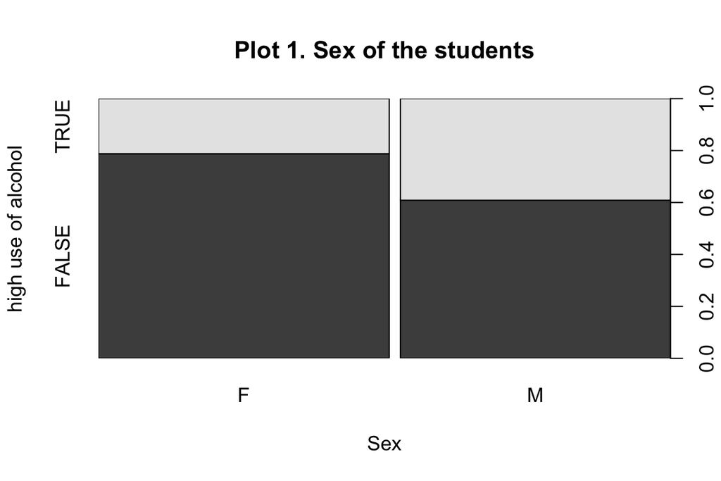

```r
## barplot SEX
plot(factor(high_use)~factor(sex), xlab="Sex", ylab="high use of alcohol", main="Plot 1. Sex of the students")
```

Table 1. shows that in both sexes there are more of those with low alcohol comsumption, but the amount with high use in males is higher (72/184) than in females (42/198). This can be seen also in the plot 1. These findings support the alternative hypothesis that there is difference between males and females.

```r
# table 2
ALC %>% group_by(high_use, romantic) %>% summarise(count = n())
```

```
## Source: local data frame [4 x 3]
## Groups: high_use [?]
##
##   high_use romantic count
##      <lgl>    <chr> <int>
## 1    FALSE       no   180
## 2    FALSE      yes    88
## 3     TRUE       no    81
## 4     TRUE      yes    33
```

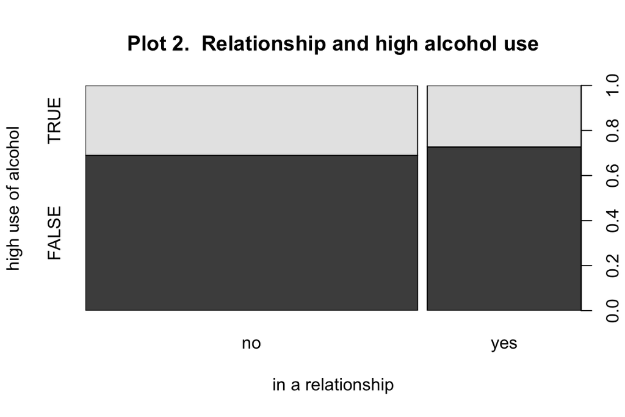

```r
# barplot ROMANTIC
plot(factor(high_use)~factor(romantic),xlab="in a relationship", ylab="high use of alcohol", main= "Plot 2.  Relationship and high alcohol use")
```

From plot 2 it can be seen that there is no difference between relationship status and high alcohol consumption. From the same plot and also from table it can be also seen that there are less people in a romantic relationship than those who are in a romantic relationship (261:121). These findings supports the null hypothesis.

```r
# table 3
ALC %>% group_by(high_use) %>% summarise(count = n(), mean_absences=mean(absences))
```

```
## # A tibble: 2 × 3
##   high_use count mean_absences
##      <lgl> <int>         <dbl>
## 1    FALSE   268      3.705224
## 2     TRUE   114      6.368421
```

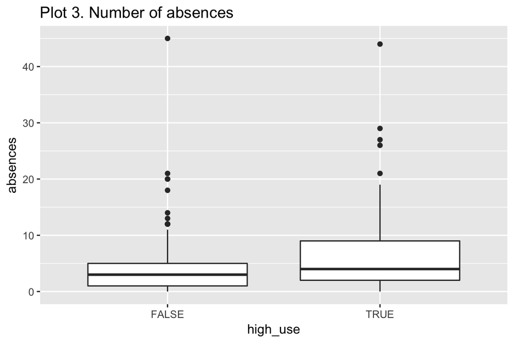

```r
# boxplot ABSENCES
g2 <- ggplot(ALC, aes(y =absences, x=high_use))
g2 + geom_boxplot() + ggtitle("Plot 3. Number of absences")
```

Table 3 shows the mean absences which seem to differ between high and low users, so that the ones who have high alcohol consumption have almost two times more absences compared to the ones with low alcohol consumption. This can be observed also from the plot 3. These support the alternative hypothese about high users having more absences.

```r
#table 4
ALC %>% group_by(high_use) %>% summarise(count = n(), mean_weekly_study_time=mean(studytime))
```

```
## # A tibble: 2 × 3
##   high_use count mean_weekly_study_time
##      <lgl> <int>                  <dbl>
## 1    FALSE   268               2.149254
## 2     TRUE   114               1.771930
```

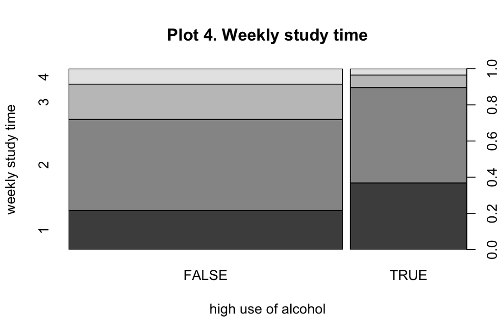

```r
# barplot STUDYTIME
spineplot(factor(studytime)~factor(high_use), xlab="high use of alcohol", ylab="weekly study time", main="Plot 4. Weekly study time")
```

Table 4. shows that the ones with low alcohol consumption uses on average more hours to study per week than the ones with high consumption. Difference can be seen in the plot 4. This suggests that the null hypothesis could possibly be rejected. To confirm these findings, they need to be tested also statistically.

### Logistic regression and odds ratios

```r
# logistic regression model with all variables
m1 <- glm(high_use ~ absences + studytime + romantic + sex, data = ALC, family = "binomial")
#  a summary of the model
summary(m1)
```

```
##
## Call:
## glm(formula = high_use ~ absences + studytime + romantic + sex,
##     family = "binomial", data = ALC)
##
## Deviance Residuals:
##     Min       1Q   Median       3Q      Max
## -2.1456  -0.8356  -0.6145   1.0895   2.0865
##
## Coefficients:
##             Estimate Std. Error z value Pr(>|z|)
## (Intercept) -0.87199    0.41840  -2.084  0.03715 *
## absences     0.09026    0.02314   3.900 9.61e-05 ***
## studytime   -0.39477    0.15916  -2.480  0.01312 *
## romanticyes -0.20370    0.26174  -0.778  0.43643
## sexM         0.78878    0.25124   3.140  0.00169 **
## ---
## Signif. codes:  0 '***' 0.001 '**' 0.01 '*' 0.05 '.' 0.1 ' ' 1
##
## (Dispersion parameter for binomial family taken to be 1)
##
##     Null deviance: 465.68  on 381  degrees of freedom
## Residual deviance: 422.66  on 377  degrees of freedom
## AIC: 432.66
##
## Number of Fisher Scoring iterations: 4
```

```r
# coefficients of the model
coef(m1)
```

```
## (Intercept)    absences   studytime romanticyes        sexM
## -0.87198682  0.09025851 -0.39477449 -0.20369623  0.78877844
```

```r
# compute odds ratios (OR)
OR <- coef(m1) %>% exp
# compute confidence intervals (CI)
CI <-confint(m1) %>% exp
# print out the odds ratios with their confidence intervals
cbind(OR, CI)
```

```
##                    OR     2.5 %    97.5 %
## (Intercept) 0.4181200 0.1829448 0.9470310
## absences    1.0944572 1.0481820 1.1479059
## studytime   0.6738320 0.4886211 0.9135379
## romanticyes 0.8157101 0.4840025 1.3541213
## sexM        2.2007065 1.3501218 3.6224923
```

### Predictive power, training error and cross-validation

```r
# model with only statistically significant variables
m2 <- glm(high_use ~ absences + studytime  + sex, data = ALC, family = "binomial")
summary(m2)
```

```
##
## Call:
## glm(formula = high_use ~ absences + studytime + sex, family = "binomial",
##     data = ALC)
##
## Deviance Residuals:
##     Min       1Q   Median       3Q      Max
## -2.1771  -0.8487  -0.5971   1.0986   2.1157
##
## Coefficients:
##             Estimate Std. Error z value Pr(>|z|)
## (Intercept) -0.91782    0.41459  -2.214  0.02684 *
## absences     0.08876    0.02308   3.846  0.00012 ***
## studytime   -0.40248    0.15930  -2.526  0.01152 *
## sexM         0.79826    0.25065   3.185  0.00145 **
## ---
## Signif. codes:  0 '***' 0.001 '**' 0.01 '*' 0.05 '.' 0.1 ' ' 1
##
## (Dispersion parameter for binomial family taken to be 1)
##
##     Null deviance: 465.68  on 381  degrees of freedom
## Residual deviance: 423.27  on 378  degrees of freedom
## AIC: 431.27
##
## Number of Fisher Scoring iterations: 4
```

```r
# predict() the probability of high_use and add it in the data
probabilities <- predict(m2, type = "response")
ALC <- mutate(ALC, probability = probabilities)

# use the probabilities to make a prediction of high_use
ALC <- mutate(ALC, prediction = probability > 0.5)
# tabulate the target variable versus the predictions
table(high_use = ALC$high_use, prediction = ALC$prediction)
```

```
##         prediction
## high_use FALSE TRUE
##    FALSE   258   10
##    TRUE     88   26
```

```r
# tabulate the target variable versus the predictions
table(high_use = ALC$high_use, prediction = ALC$prediction) %>% prop.table() %>% addmargins()
```

```
##         prediction
## high_use      FALSE       TRUE        Sum
##    FALSE 0.67539267 0.02617801 0.70157068
##    TRUE  0.23036649 0.06806283 0.29842932
##    Sum   0.90575916 0.09424084 1.00000000
```

```r
## training error
# define a loss function (mean prediction error)
loss_func <- function(class, prob) {
  n_wrong <- abs(class - prob) > 0.5
  mean(n_wrong)
}
loss_func(class = ALC$high_use, prob = ALC$probability)
```

```
## [1] 0.2565445
```

```r
# 10-fold cross-validation
library(boot)
cv <- cv.glm(data = ALC, cost = loss_func, glmfit = m2, K = 10)
# average number of wrong predictions in the cross validation
cv$delta[1]
```

```
## [1] 0.2617801
```

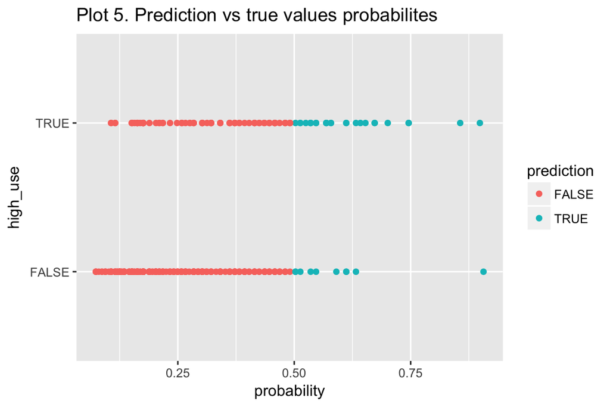

```r
# Plot 5. Predictions
g <- ggplot(ALC, aes(x = probability, y = high_use, col= prediction))
g + geom_point()+ggtitle("Plot 5. Prediction vs true values probabilites")
```